# 01-Prediction

# Your Turn 1

Write a pipe that creates a learner that uses `lm()` to fit a linear regression. Save it as `lm_spec` and look at the object. What does it return?

```r
lm_spec <- linear_reg() %>%
  set_engine(engine = "lm")
lm_spec
```

```
## Linear Regression Model Specification (regression)
##
## Computational engine: lm
```

# Your Turn 2

Double check. Does

```r
lm_fit <- fit_data(Sale_Price ~ Gr_Liv_Area, model = lm_spec, data = ames)
lm_fit
```

```
## ══ Workflow [trained] ═══════════════════════════════════════════════════════════════════════════════════════════════════
## Preprocessor: Formula
## Model: linear_reg()
##
## ── Preprocessor ─────────────────────────────────────────────────────────────────────────────────────────────────────────
## Sale_Price ~ Gr_Liv_Area
##
## ── Model ────────────────────────────────────────────────────────────────────────────────────────────────────────────────
##
## Call:
## stats::lm(formula = ..y ~ ., data = data)
##
## Coefficients:
## (Intercept)  Gr_Liv_Area
##     13289.6        111.7
```

give the same results as

```r
lm(Sale_Price ~ Gr_Liv_Area, data = ames)
```

```
##
## Call:
## lm(formula = Sale_Price ~ Gr_Liv_Area, data = ames)
##
## Coefficients:
## (Intercept)  Gr_Liv_Area
##     13289.6        111.7
```

# Your Turn 3

Fill in the blanks. Use `predict()` to

1. Use your linear model to predict sale prices; save the tibble as `price_pred`
2. Add a pipe and use `mutate()` to add a column with the observed sale prices; name it `truth`

```r
lm_fit <- fit_data(Sale_Price ~ Gr_Liv_Area,
                   model = lm_spec,
                   data = ames)

price_pred <- lm_fit %>%
  predict(new_data = ames) %>%
  mutate(truth = ames$Sale_Price)

price_pred
```

```
## # A tibble: 2,930 x 2
##      .pred  truth
##      <dbl>  <int>
##  1 198255. 215000
##  2 113367. 105000
##  3 161731. 172000
##  4 248964. 244000
##  5 195239. 189900
##  6 192447. 195500
##  7 162736. 213500
##  8 156258. 191500
##  9 193787. 236500
## 10 214786. 189000
## # … with 2,920 more rows
```

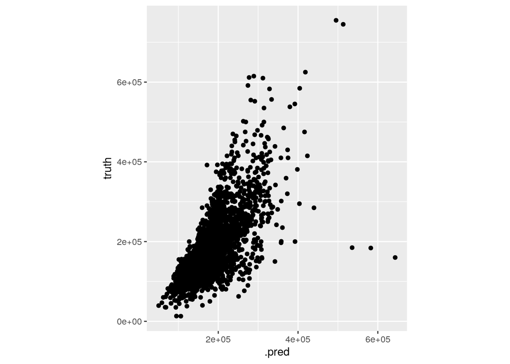

```r
ggplot(price_pred, aes(.pred, truth)) +
  geom_point() +
  coord_fixed()
```

# Your Turn 4

In your teams, decide which model:

1. Has the smallest residuals
2. Will have lower prediction error. Why?

# Your Turn 5

Fill in the blanks.

Use `initial_split()`, `training()`, `testing()`, `lm()` and `rmse()` to:

1. Split **ames** into training and test sets. Save the rsplit!
2. Extract the training data. Fit a linear model to it. Save the model!
3. Measure the RMSE of your linear model with your test set.

Keep `set.seed(100)` at the start of your code.

*Hint: Be sure to remove every `_` before running the code!*

```r
set.seed(100) # Important!

ames_split  <- initial_split(ames, prop = 3/4)
ames_train  <- training(ames_split)
ames_test   <- testing(ames_split)

lm_fit      <- fit_data(Sale_Price ~ Gr_Liv_Area,
                        model = lm_spec,
                        data = ames_train)
lm_fit
```

```
## ══ Workflow [trained] ═══════════════════════════════════════════════════════════════════════════════════════════════════
## Preprocessor: Formula
## Model: linear_reg()
##
## ── Preprocessor ─────────────────────────────────────────────────────────────────────────────────────────────────────────
## Sale_Price ~ Gr_Liv_Area
##
## ── Model ────────────────────────────────────────────────────────────────────────────────────────────────────────────────
##
## Call:
## stats::lm(formula = ..y ~ ., data = data)
##
## Coefficients:
## (Intercept)  Gr_Liv_Area
##     16846.0        109.3
```

```r
price_pred  <- lm_fit %>%
  predict(new_data = ames_test) %>%
  mutate(price_truth = ames_test$Sale_Price)

rmse_test <- rmse(price_pred, truth = price_truth, estimate = .pred)
rmse_test
```

```
## # A tibble: 1 x 3
##   .metric .estimator .estimate
##   <chr>   <chr>          <dbl>
## 1 rmse    standard      53885.
```

# Your Turn 6

Rewrite your code from the previous exercise using `fit_split()` and `collect_metrics()` to:

1. Split **ames** into training and test sets. Save the rsplit!
2. Fit a linear model to the training set, then use the model to predict new observations from the test set.
3. Extract the rmse- is it the same as what we just calculated in our previous exercise 5.388510^{4}?

Keep `set.seed(100)` at the start of your code.

```r
lm_fit_split      <- fit_split(Sale_Price ~ Gr_Liv_Area,
                        model = lm_spec,
                        split = ames_split)
lm_fit_split
```

```
## # Resampling results
## # Monte Carlo cross-validation (0.75/0.25) with 1 resamples
## # A tibble: 1 x 6
##   splits        id           .metrics      .notes      .predictions    .workflow
##   <list>        <chr>        <list>        <list>      <list>          <list>
## 1 <split [2.2K… train/test … <tibble [2 ×… <tibble [0… <tibble [732 ×… <workflo…
```

```r
price_pred_split  <- lm_fit_split %>%
  collect_metrics()
price_pred_split
```

```
## # A tibble: 2 x 3
##   .metric .estimator .estimate
##   <chr>   <chr>          <dbl>
## 1 rmse    standard   53885.
## 2 rsq     standard       0.568
```

```r
rmse(price_pred, truth = price_truth, estimate = .pred)
```

```
## # A tibble: 1 x 3
##   .metric .estimator .estimate
##   <chr>   <chr>          <dbl>
## 1 rmse    standard      53885.
```

# Your Turn 7

Write a pipe to create a model that uses the rpart package to fit a regression tree. Use `fit_split()` and `collect_metrics()` to compare the RMSE here to one using the linear model for the same formula- which is better?

*Hint: you’ll need https://tidymodels.github.io/parsnip/articles/articles/Models.html*

```r
rt_spec <-
  decision_tree() %>%
  set_engine(engine = "rpart") %>%
  set_mode("regression")

set.seed(100) # Important!
fit_split(Sale_Price ~ Gr_Liv_Area,
          model = rt_spec,
          split = ames_split) %>%
  collect_metrics()
```

```
## # A tibble: 2 x 3
##   .metric .estimator .estimate
##   <chr>   <chr>          <dbl>
## 1 rmse    standard   56055.
## 2 rsq     standard       0.529
```

# Your Turn 11

Write *another* pipe to create a model that uses the kknn package to fit a K nearest neighbors model. Use `fit_split()` and `collect_metrics()` to compare the RMSE here to our other models with the same formula- which is better?

*Hint: you’ll need https://tidymodels.github.io/parsnip/articles/articles/Models.html*

```r
nn_spec <- nearest_neighbor() %>%
  set_engine(engine = "kknn") %>%
  set_mode("regression")

fit_split(Sale_Price ~ Gr_Liv_Area,
          model = nn_spec,
          split = ames_split) %>%
  collect_metrics()
```

```
## # A tibble: 2 x 3
##   .metric .estimator .estimate
##   <chr>   <chr>          <dbl>
## 1 rmse    standard   59074.
## 2 rsq     standard       0.485
```